# How to break a t-test

Steph and John

2019-04-11

# Intro Banter

**Steph**: How about we take one from the fans this week?

**John**: I’m up for it. Let’s go.

**Steph**: Here is a question from Dean.

> Ok so dont all jump on this at once, but thoughts on transforming non-normal data to satisfy assumptions of a t-test? [#rstats](https://twitter.com/hashtag/rstats?src=hash&ref_src=twsrc%5Etfw) [#stats](https://twitter.com/hashtag/stats?src=hash&ref_src=twsrc%5Etfw)

> — Dean Marchiori (@deanmarchiori) [April 9, 2019](https://twitter.com/deanmarchiori/status/1115447019449925632?ref_src=twsrc%5Etfw)

**John**: Let’s start by reviewing the two sample t-test and then let’s break it.

**Steph**: You know how I like to break things!

# The two sample t-test

Suppose that we have two groups of samples ${\bf X} = (X_1,\ldots,X_{n_X})$ and ${\bf Y} = (Y_1,\ldots,Y_{n_Y})$. Often we want to test whether the two groups of samples come from the same distribution. A simplifying assumption to model the $X_i$’s and $Y_i$’s using
$$X_i \stackrel{iid}{\sim} N(\mu_X,\sigma^2)
\qquad\mbox{and} \qquad
Y_i \stackrel{iid}{\sim} N(\mu_Y,\sigma^2)$$
where the $X_i$’s and $Y_i$’s are themselves independent random variabes, and so we wish to test the hypotheses
$$H_0 \colon \mu_X = \mu_Y
\qquad \mbox{versus} \qquad
H_1 \colon \mu_X \ne \mu_Y.$$
Then the two-sample test statistic is given by
$$T({\bf X},{\bf Y}) = \frac{\overline{X} - \overline{Y}}{S_p \sqrt{ \frac{1}{n_X} + \frac{1}{n_Y}}}$$
where the “pooled” variance estimate for group $X$ and group $Y$ is given by
$$S_p^2 = \frac{(n_X - 1)S_X^2 + (n_Y - 1)S_Y^2}{n_X + n_Y - 2}.$$

If $X_i \sim N(\mu_X,\sigma^2)$, $Y_i~\sim N(\mu_X,\sigma^2)$ and $\mu_X = \mu_Y$ then
$$T({\bf X},{\bf Y}) \sim t_{n_X + n_Y - 2}$$

and the (2-sided) $p$-value for this test is
$$p = 2 \ {\mathbb P}( t_{n_X + n_Y - 2} > | T({\bf x},{\bf y})| )$$
where ${\bf x} = (x_1,\ldots,x_{n_X})$ and ${\bf y} = (y_1,\ldots,y_{n_Y})$ are the observed sampes for group $X$ and group $Y$ respectively.

Futhermore, if the $X_i$’s and the $Y_i$’s are not normally distributed but the means and variances of $X$ and $Y$ exist and are finite then the central limit theorm can be used to show that
$$T({\bf X},{\bf Y}) \stackrel{approx.}{\sim} N(0,1).$$
and the (2-sided) $p$-value is then calculated via
$$p = 2 \ {\mathbb P}( Z > | T({\bf x},{\bf y})| )$$
where $Z\sim N(0,1)$.

# What are the main assumptions

Can break (give false conclusion that means are different) when

1. Not independent observations.
2. Not identically distributed (outliers, confounding)
3. Not normal data.
4. Artificially small variance.

```r
plot_dist <- function(distname,N=300,...)
{
  # use the "get" function to, for example, turn the
  # string "norm" into the functions dnorm and qnorm
  ddist <- get(paste("d",distname,sep=""))
  qdist <- get(paste("q",distname,sep=""))

  # Calculate a nice grid of x values and density
  xlim <- qdist(c(0.0001,0.9999),...)
  x <- seq(xlim[1],xlim[2],,N)
  y <- ddist(x,...)

  return(tibble(x=x,y=y))
}
```

# Do skewed densities kill the two sample t-test?

The two sample t-test is robust to a whole range of non-normal distributions for the $X_i$ and $Y_i$’s thanks to the CLT. To look at some of the ways the CLT can break consider (How to break the CLT)[./CLT_orig.html]

To explore this in the context of the two sample t-test we are going to simulate data from two skewed normal densities. There are a number of different skewed normal densities. These are generalizations of normal densities which allow for skewness.

We will choose skew normal densities of the form
$$f(x;\xi,\omega,\alpha) = 2 \ \phi\left( \frac{x - \xi}{\omega} \right) \Phi\left( \alpha \left( \frac{x - \xi}{\omega}\right) \right)$$
which is a density on $-\infty < x < \infty$ with $\xi$, $\omega$, and $\alpha$ being the being the location, scale and skewness parameters repsectively. When $\alpha = 0$ this reduces to the normal distribution.

The mean and variance are given by
$${\mathbb E}(X) = \xi + \sqrt{\frac{2}{\pi}} \frac{\omega\alpha}{\sqrt{1 + \alpha}}
\qquad \mbox{and} \qquad
\mbox{Var}(X) = \omega^2\left( 1 - \frac{2}{\pi}\frac{\alpha^2}{1 + \alpha^2} \right )$$
respectively. The `R` functions assoicated with the skew normal distirubiton can be found in the `sn` library.

We will now look at the case where we have two skewed normal distirbutions of the form
$$X_i \sim SN\left( -\sqrt{\frac{2}{\pi}}\frac{\alpha}{\sqrt{1 + \alpha^2}}, 1, \alpha\right)
\qquad\mbox{and} \qquad
Y_i \sim SN\left( \sqrt{\frac{2}{\pi}}\frac{\alpha}{\sqrt{1 + \alpha^2}}, 1, -\alpha\right)$$

where $\alpha = 30$ which correspond to very skewed densities.

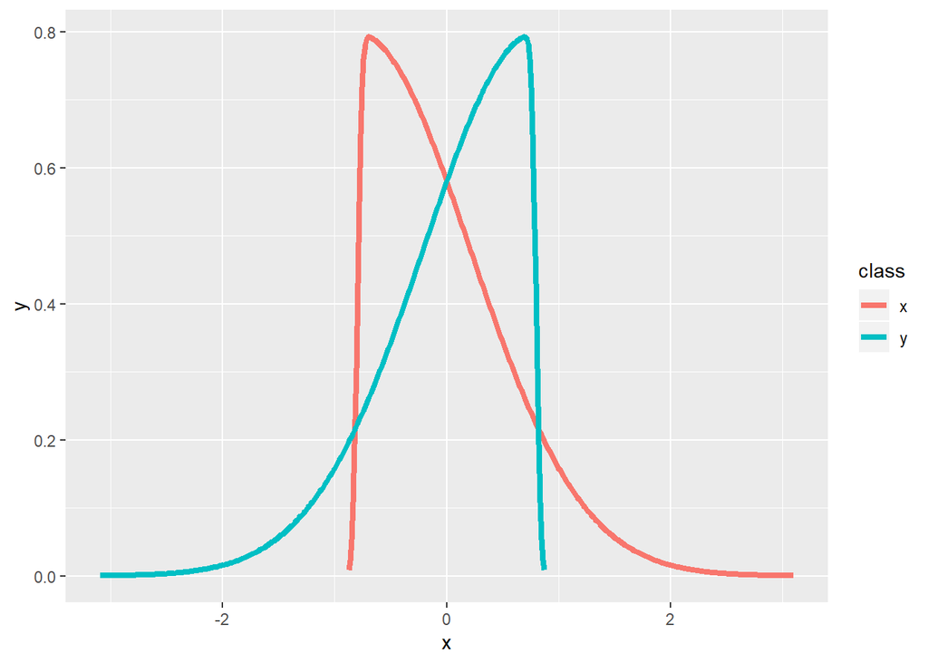

```r
library(sn)
library(tidyverse)

alpha <- 30
mu <- sqrt(2/pi)*alpha/sqrt(1 + alpha^2)
dens1 <- plot_dist("sn",N=300,xi=-mu,alpha= alpha)
dens2 <- plot_dist("sn",N=300,xi= mu,alpha=-alpha)

tib1 <- tibble(x=dens1$x,y=dens1$y,class="x")
tib2 <- tibble(x=dens2$x,y=dens2$y,class="y")
tib <- bind_rows(tib1,tib2)

g <- tib %>%
  ggplot(aes(x=x,y=y,color=class))  +
  geom_line(size=1.5)
g
```

Let’s now create a function to calculate the two sample t-test statistic.

```r
t_stat <- function(x,y)
{
  nx <- length(x)
  ny <- length(y)
  s2p <- ((nx-1)*var(x) + (ny-1)*var(y))/(nx + ny - 2)
  tval <- (mean(x) - mean(y))/(sqrt(s2p)*sqrt(1/nx + 1/ny))
  return(tval)
}
```

Let’s now simulate from the above skewed densities for the $X_i$’s and the $Y_i$’s where $n_X = n_Y = 25$ and cacluate the test statistic $T({\bf X},{\bf Y})$ for $N = 100000$ different instances of ${\bf X}$ and ${\bf Y}$.

```r
N <- 100000
nx <- 25
ny <- 25

t_vec <- c()
for (i in 1:N)
{
  x <- rsn(nx,xi=-mu,alpha= alpha)
  y <- rsn(ny,xi= mu,alpha=-alpha)
  t_vec[i] <- t_stat(x,y)
}
```

Let’s now plot the distribution of these $N=100000$ test statistics against the theoretical standard normal distribution.

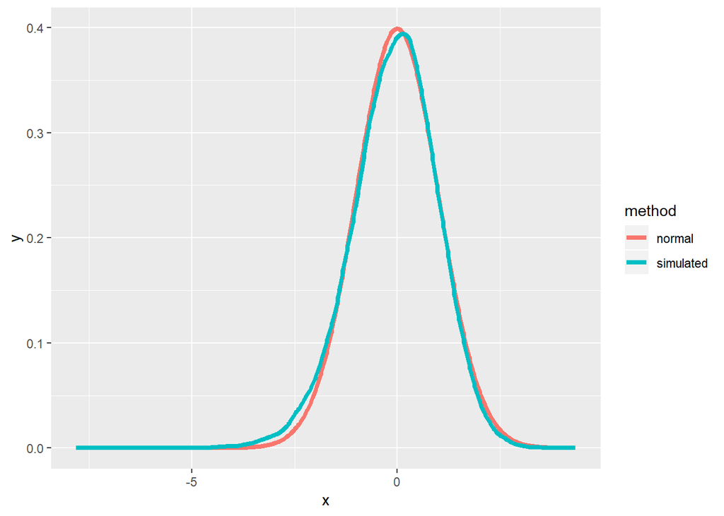

```r
dens <- density(t_vec)
tib1 <- tibble(x=dens$x,y=dens$y,method="simulated")
tib2 <- tibble(x=dens$x,y=dnorm(dens$x),method="normal")
tib <- bind_rows(tib1,tib2)

g <- tib %>%
  ggplot(aes(x=x,y=y,color=method))  +
  geom_line(size=1.5)
g
```

As we can see the the theoretical standard normal and the density estimate of the simulated test statistics are very close to one anohter.

This is expected.

Things that will kill the two sample t-test include densities with very heavy tails.

# Do very heavy tailed densities kill the two sample t-test?

$$X_i \sim SN\left( -\sqrt{\frac{2}{\pi}}\frac{\alpha}{\sqrt{1 + \alpha^2}}, 1, \alpha\right)
\qquad\mbox{and} \qquad
Y_i \sim t_{3/2}$$

Now both densities have zero mean by construction. However, now the $Y_i$’s don’t have a finite variance.

```r
N <- 10000000
nx <- 100
ny <- 100

t_vec <- c()
for (i in 1:N)
{
  x <- rsn(nx,xi=-mu,alpha= alpha)
  y <- rt(ny,df=1.5)
  t_vec[i] <- t_stat(x,y)
}

save(t_vec,file="t_vec.Rdata")
```

When we look at the density plot of the test statistic we get.

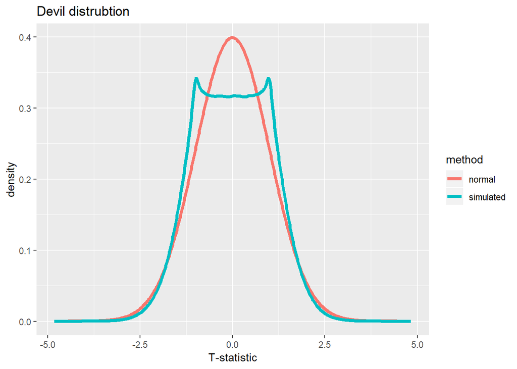

```r
load("t_vec.Rdata")

dens <- density(t_vec)
tib1 <- tibble(x=dens$x,y=dens$y,method="simulated")
tib2 <- tibble(x=dens$x,y=dnorm(dens$x),method="normal")
tib <- bind_rows(tib1,tib2)

g <- tib %>%
  ggplot(aes(x=x,y=y,color=method))  +
  geom_line(size=1.5) +
  labs(title="Devil distrubtion",x='T-statistic',y='density')
g
```

```r
ggsave("DevilDist.png")
```

# Do outliers kill the two sample t-test?

$$X_i \sim SN\left( -\sqrt{\frac{2}{\pi}}\frac{\alpha}{\sqrt{1 + \alpha^2}}, 1, \alpha\right)$$

```r
N <- 100000
nx <- 100
ny <- 100

t_vec <- c()
for (i in 1:N)
{
  x <- rsn(nx,xi=-mu,alpha= alpha)
  b <- rbinom(ny,1,0.99)
  y <- b*rnorm(ny) + (1 - b)*rnorm(ny,4,1)
  t_vec[i] <- t_stat(x,y)
}

p_vec <- 2*pnorm(abs(t_vec),lower.tail=FALSE)
```

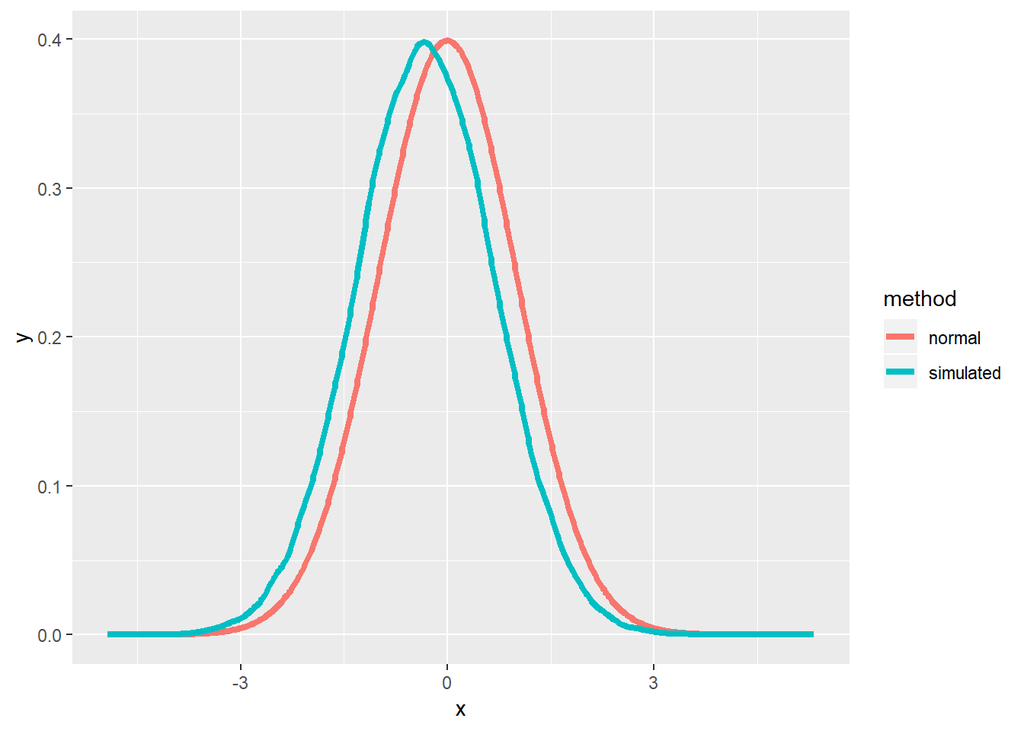

```r
dens <- density(t_vec)
tib1 <- tibble(x=dens$x,y=dens$y,method="simulated")
tib2 <- tibble(x=dens$x,y=dnorm(dens$x),method="normal")
tib <- bind_rows(tib1,tib2)

g <- tib %>%
  ggplot(aes(x=x,y=y,color=method))  +
  geom_line(size=1.5)
g
```

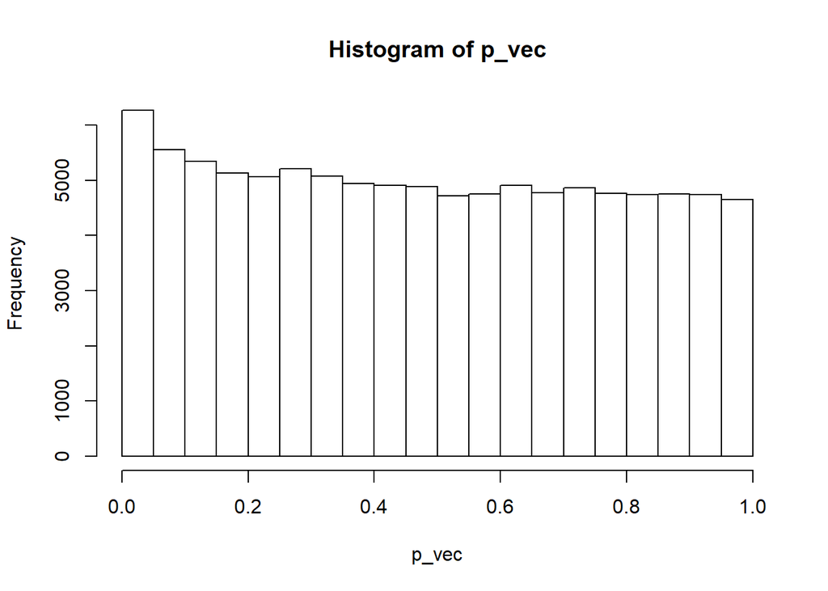

```r
hist(p_vec)
```